# 目录

## 项目介绍

- 此次项目数据来自Kaggle，包含了2010年12月1日至2011年12月9日在英国注册的非实体网上零售发主的所有交易。公司主要销售独特的全天候礼品。该公司的许多客户都是批发商。
- 字段如下:
- InvoiceNo:订单续号，每笔交易有6个整数，退货订单编号开头有字母.
- StockCode: 产品编号，由5个整数组成Description:产品描述。
- Quantity.产品数型，有负号的表示退货
- InvoiceDate: 订单日期和时间
- UnitPrice:单价(英镑)，单位产品的价格
- CustomerID:客户编号，梅个客户编号由5位数字组成
- Country.国家的名称，每个客户所在回家/地区的名称
- Description.产品描述

## 分析目的

- RFM模型
- 用户分类 (RFM模型)，对比分析不同用户群体在时间、地区等维度下交易量，交易金额指标，并根据分析结果提出优化建议
- R:近一次消费时间(最近一次消费到参考时间的长度)
- F:消费的频次(单位时间内消费了多少次)
- M:消费的金额(单位时间内总消费金额)

```python
import os
import numpy as np
import pandas as pd
import warnings
import matplotlib.pyplot as plt
import seaborn as sns
sns.set(style='darkgrid')
warnings.filterwarnings('ignore')
```

```python
plt.rcParams['font.sans-serif'] = 'SimHei'
plt.rcParams['axes.unicode_minus'] = False
```

```python
df = pd.read_csv('data.csv')
```

```python
df.info()
```

```
<class 'pandas.core.frame.DataFrame'>
RangeIndex: 541909 entries, 0 to 541908
Data columns (total 8 columns):
InvoiceNo      541909 non-null object
StockCode      541909 non-null object
Description    540455 non-null object
Quantity       541909 non-null int64
InvoiceDate    541909 non-null object
UnitPrice      541909 non-null float64
CustomerID     406829 non-null float64
Country        541909 non-null object
dtypes: float64(2), int64(1), object(5)
memory usage: 33.1+ MB
```

```python
df.head()
```

|  | InvoiceNo | StockCode | Description | Quantity | InvoiceDate | UnitPrice | CustomerID | Country |
| --- | --- | --- | --- | --- | --- | --- | --- | --- |
| 0 | 536365 | 85123A | WHITE HANGING HEART T-LIGHT HOLDER | 6 | 12/1/2010 8:26 | 2.55 | 17850.0 | United Kingdom |
| 1 | 536365 | 71053 | WHITE METAL LANTERN | 6 | 12/1/2010 8:26 | 3.39 | 17850.0 | United Kingdom |
| 2 | 536365 | 84406B | CREAM CUPID HEARTS COAT HANGER | 8 | 12/1/2010 8:26 | 2.75 | 17850.0 | United Kingdom |
| 3 | 536365 | 84029G | KNITTED UNION FLAG HOT WATER BOTTLE | 6 | 12/1/2010 8:26 | 3.39 | 17850.0 | United Kingdom |
| 4 | 536365 | 84029E | RED WOOLLY HOTTIE WHITE HEART. | 6 | 12/1/2010 8:26 | 3.39 | 17850.0 | United Kingdom |

## 数据清洗

```python
#计算缺失率
online_data = df.copy()
online_data.apply(lambda x: (x.isnull().sum())/len(online_data),axis = 0)
```

```
InvoiceNo      0.000000
StockCode      0.000000
Description    0.002683
Quantity       0.000000
InvoiceDate    0.000000
UnitPrice      0.000000
CustomerID     0.249267
Country        0.000000
dtype: float64
```

可以看出，CustomerID的缺失率达到25%，Description商品描述有缺失，但对分析问题无影响故删除该列，因为CustomerID不能随便删除，所以将缺失值用U填充

```python
online_data.drop(['Description'],axis=1,inplace=True)
```

```python
# online_data.head()
```

```python
online_data['CustomerID'].fillna('U',inplace= True)
```

```python
online_data.apply(lambda x: (x.isnull().sum())/len(online_data),axis = 0)#再次查看缺失率
```

```
InvoiceNo      0.0
StockCode      0.0
Quantity       0.0
InvoiceDate    0.0
UnitPrice      0.0
CustomerID     0.0
Country        0.0
dtype: float64
```

```python
#计算总价amount
online_data['amount'] = online_data['Quantity'] * online_data['UnitPrice']
```

```python
online_data.head()
```

|  | InvoiceNo | StockCode | Quantity | InvoiceDate | UnitPrice | CustomerID | Country | amount |
| --- | --- | --- | --- | --- | --- | --- | --- | --- |
| 0 | 536365 | 85123A | 6 | 12/1/2010 8:26 | 2.55 | 17850 | United Kingdom | 15.30 |
| 1 | 536365 | 71053 | 6 | 12/1/2010 8:26 | 3.39 | 17850 | United Kingdom | 20.34 |
| 2 | 536365 | 84406B | 8 | 12/1/2010 8:26 | 2.75 | 17850 | United Kingdom | 22.00 |
| 3 | 536365 | 84029G | 6 | 12/1/2010 8:26 | 3.39 | 17850 | United Kingdom | 20.34 |
| 4 | 536365 | 84029E | 6 | 12/1/2010 8:26 | 3.39 | 17850 | United Kingdom | 20.34 |

```python
#将InvoiceDate分为两列分别为date和time
online_data['date'] = [x.split(' ')[0] for x in online_data['InvoiceDate']]
online_data['time'] = [x.split(' ')[1] for x in online_data['InvoiceDate']]
```

```python
# [x.split(' ')[0] for x in online_data['InvoiceDate']]
```

```python
online_data.head()
```

|  | InvoiceNo | StockCode | Quantity | InvoiceDate | UnitPrice | CustomerID | Country | amount | date | time |
| --- | --- | --- | --- | --- | --- | --- | --- | --- | --- | --- |
| 0 | 536365 | 85123A | 6 | 12/1/2010 8:26 | 2.55 | 17850 | United Kingdom | 15.30 | 12/1/2010 | 8:26 |
| 1 | 536365 | 71053 | 6 | 12/1/2010 8:26 | 3.39 | 17850 | United Kingdom | 20.34 | 12/1/2010 | 8:26 |
| 2 | 536365 | 84406B | 8 | 12/1/2010 8:26 | 2.75 | 17850 | United Kingdom | 22.00 | 12/1/2010 | 8:26 |
| 3 | 536365 | 84029G | 6 | 12/1/2010 8:26 | 3.39 | 17850 | United Kingdom | 20.34 | 12/1/2010 | 8:26 |
| 4 | 536365 | 84029E | 6 | 12/1/2010 8:26 | 3.39 | 17850 | United Kingdom | 20.34 | 12/1/2010 | 8:26 |

```python
online_data['date'] = pd.to_datetime(online_data['date'])
```

```python
online_data.head()
```

|  | InvoiceNo | StockCode | Quantity | InvoiceDate | UnitPrice | CustomerID | Country | amount | date | time |
| --- | --- | --- | --- | --- | --- | --- | --- | --- | --- | --- |
| 0 | 536365 | 85123A | 6 | 12/1/2010 8:26 | 2.55 | 17850 | United Kingdom | 15.30 | 2010-12-01 | 8:26 |
| 1 | 536365 | 71053 | 6 | 12/1/2010 8:26 | 3.39 | 17850 | United Kingdom | 20.34 | 2010-12-01 | 8:26 |
| 2 | 536365 | 84406B | 8 | 12/1/2010 8:26 | 2.75 | 17850 | United Kingdom | 22.00 | 2010-12-01 | 8:26 |
| 3 | 536365 | 84029G | 6 | 12/1/2010 8:26 | 3.39 | 17850 | United Kingdom | 20.34 | 2010-12-01 | 8:26 |
| 4 | 536365 | 84029E | 6 | 12/1/2010 8:26 | 3.39 | 17850 | United Kingdom | 20.34 | 2010-12-01 | 8:26 |

```python
#提取年和月日的数值
online_data['year'] = online_data['date'].dt.year
online_data['month'] = online_data['date'].dt.month
online_data['day'] = online_data['date'].dt.day
```

```python
online_data.head()
```

|  | InvoiceNo | StockCode | Quantity | InvoiceDate | UnitPrice | CustomerID | Country | amount | date | time | year | month | day |
| --- | --- | --- | --- | --- | --- | --- | --- | --- | --- | --- | --- | --- | --- |
| 0 | 536365 | 85123A | 6 | 12/1/2010 8:26 | 2.55 | 17850 | United Kingdom | 15.30 | 2010-12-01 | 8:26 | 2010 | 12 | 1 |
| 1 | 536365 | 71053 | 6 | 12/1/2010 8:26 | 3.39 | 17850 | United Kingdom | 20.34 | 2010-12-01 | 8:26 | 2010 | 12 | 1 |
| 2 | 536365 | 84406B | 8 | 12/1/2010 8:26 | 2.75 | 17850 | United Kingdom | 22.00 | 2010-12-01 | 8:26 | 2010 | 12 | 1 |
| 3 | 536365 | 84029G | 6 | 12/1/2010 8:26 | 3.39 | 17850 | United Kingdom | 20.34 | 2010-12-01 | 8:26 | 2010 | 12 | 1 |
| 4 | 536365 | 84029E | 6 | 12/1/2010 8:26 | 3.39 | 17850 | United Kingdom | 20.34 | 2010-12-01 | 8:26 | 2010 | 12 | 1 |

```python
#删除原来的时间列
online_data.drop(['InvoiceDate'],axis=1,inplace = True)
```

```python
online_data.head()
```

|  | InvoiceNo | StockCode | Quantity | UnitPrice | CustomerID | Country | amount | date | time | year | month | day |
| --- | --- | --- | --- | --- | --- | --- | --- | --- | --- | --- | --- | --- |
| 0 | 536365 | 85123A | 6 | 2.55 | 17850 | United Kingdom | 15.30 | 2010-12-01 | 8:26 | 2010 | 12 | 1 |
| 1 | 536365 | 71053 | 6 | 3.39 | 17850 | United Kingdom | 20.34 | 2010-12-01 | 8:26 | 2010 | 12 | 1 |
| 2 | 536365 | 84406B | 8 | 2.75 | 17850 | United Kingdom | 22.00 | 2010-12-01 | 8:26 | 2010 | 12 | 1 |
| 3 | 536365 | 84029G | 6 | 3.39 | 17850 | United Kingdom | 20.34 | 2010-12-01 | 8:26 | 2010 | 12 | 1 |
| 4 | 536365 | 84029E | 6 | 3.39 | 17850 | United Kingdom | 20.34 | 2010-12-01 | 8:26 | 2010 | 12 | 1 |

```python
#重复值处理
online_data.drop_duplicates(inplace=True)
```

```python
#异常值数据探索
online_data.describe()
```

|  | Quantity | UnitPrice | amount | year | month | day |
| --- | --- | --- | --- | --- | --- | --- |
| count | 536639.000000 | 536639.000000 | 536639.000000 | 536639.000000 | 536639.000000 | 536639.000000 |
| mean | 9.619500 | 4.632660 | 18.122900 | 2010.921771 | 7.544819 | 15.024639 |
| std | 219.130206 | 97.233299 | 380.656313 | 0.268533 | 3.508697 | 8.663358 |
| min | -80995.000000 | -11062.060000 | -168469.600000 | 2010.000000 | 1.000000 | 1.000000 |
| 25% | 1.000000 | 1.250000 | 3.750000 | 2011.000000 | 5.000000 | 7.000000 |
| 50% | 3.000000 | 2.080000 | 9.870000 | 2011.000000 | 8.000000 | 15.000000 |
| 75% | 10.000000 | 4.130000 | 17.400000 | 2011.000000 | 11.000000 | 22.000000 |
| max | 80995.000000 | 38970.000000 | 168469.600000 | 2011.000000 | 12.000000 | 31.000000 |

```python
#剔除单价为负值的数值（退货）
df2 = online_data[online_data['UnitPrice'] <=0]
```

```python
# df2
```

```python
# df3 =  online_data.loc[online_data['UnitPrice'] < 0] df2 = df3
```

```python
df2.shape[0] / online_data.shape[0]#计算异常比例
```

```
0.0046809866595607106
```

```python
len(df2) / len(online_data)#与上式相等
```

```
0.0046809866595607106
```

```python
# df2.shape[0]#计算的是行数
```

```python
df2['UnitPrice'].groupby(df2['UnitPrice']).count()#这是序列分组
```

```
UnitPrice
-11062.06       2
 0.00        2510
Name: UnitPrice, dtype: int64
```

## 数据分析

### 分析退货率

```python
#统计退货情况
df1 = online_data.loc[online_data['Quantity'] <= 0]
```

```python
df1.columns
```

```
Index(['InvoiceNo', 'StockCode', 'Quantity', 'UnitPrice', 'CustomerID',
       'Country', 'amount', 'date', 'time', 'year', 'month', 'day'],
      dtype='object')
```

```python
df1
```

|  | InvoiceNo | StockCode | Quantity | UnitPrice | CustomerID | Country | amount | date | time | year | month | day |
| --- | --- | --- | --- | --- | --- | --- | --- | --- | --- | --- | --- | --- |
| 141 | C536379 | D | -1 | 27.50 | 14527 | United Kingdom | -27.50 | 2010-12-01 | 9:41 | 2010 | 12 | 1 |
| 154 | C536383 | 35004C | -1 | 4.65 | 15311 | United Kingdom | -4.65 | 2010-12-01 | 9:49 | 2010 | 12 | 1 |
| 235 | C536391 | 22556 | -12 | 1.65 | 17548 | United Kingdom | -19.80 | 2010-12-01 | 10:24 | 2010 | 12 | 1 |
| 236 | C536391 | 21984 | -24 | 0.29 | 17548 | United Kingdom | -6.96 | 2010-12-01 | 10:24 | 2010 | 12 | 1 |
| 237 | C536391 | 21983 | -24 | 0.29 | 17548 | United Kingdom | -6.96 | 2010-12-01 | 10:24 | 2010 | 12 | 1 |
| 238 | C536391 | 21980 | -24 | 0.29 | 17548 | United Kingdom | -6.96 | 2010-12-01 | 10:24 | 2010 | 12 | 1 |
| 239 | C536391 | 21484 | -12 | 3.45 | 17548 | United Kingdom | -41.40 | 2010-12-01 | 10:24 | 2010 | 12 | 1 |
| 240 | C536391 | 22557 | -12 | 1.65 | 17548 | United Kingdom | -19.80 | 2010-12-01 | 10:24 | 2010 | 12 | 1 |
| 241 | C536391 | 22553 | -24 | 1.65 | 17548 | United Kingdom | -39.60 | 2010-12-01 | 10:24 | 2010 | 12 | 1 |
| 939 | C536506 | 22960 | -6 | 4.25 | 17897 | United Kingdom | -25.50 | 2010-12-01 | 12:38 | 2010 | 12 | 1 |
| 1441 | C536543 | 22632 | -1 | 2.10 | 17841 | United Kingdom | -2.10 | 2010-12-01 | 14:30 | 2010 | 12 | 1 |
| 1442 | C536543 | 22355 | -2 | 0.85 | 17841 | United Kingdom | -1.70 | 2010-12-01 | 14:30 | 2010 | 12 | 1 |
| 1973 | C536548 | 22244 | -4 | 1.95 | 12472 | Germany | -7.80 | 2010-12-01 | 14:33 | 2010 | 12 | 1 |
| 1974 | C536548 | 22242 | -5 | 1.65 | 12472 | Germany | -8.25 | 2010-12-01 | 14:33 | 2010 | 12 | 1 |
| 1975 | C536548 | 20914 | -1 | 2.95 | 12472 | Germany | -2.95 | 2010-12-01 | 14:33 | 2010 | 12 | 1 |
| 1976 | C536548 | 22892 | -7 | 1.25 | 12472 | Germany | -8.75 | 2010-12-01 | 14:33 | 2010 | 12 | 1 |
| 1977 | C536548 | 22654 | -1 | 5.95 | 12472 | Germany | -5.95 | 2010-12-01 | 14:33 | 2010 | 12 | 1 |
| 1978 | C536548 | 22767 | -2 | 9.95 | 12472 | Germany | -19.90 | 2010-12-01 | 14:33 | 2010 | 12 | 1 |
| 1979 | C536548 | 22333 | -1 | 1.65 | 12472 | Germany | -1.65 | 2010-12-01 | 14:33 | 2010 | 12 | 1 |
| 1980 | C536548 | 22245 | -2 | 0.85 | 12472 | Germany | -1.70 | 2010-12-01 | 14:33 | 2010 | 12 | 1 |
| 1981 | C536548 | 22077 | -6 | 1.65 | 12472 | Germany | -9.90 | 2010-12-01 | 14:33 | 2010 | 12 | 1 |
| 1982 | C536548 | 22631 | -1 | 1.95 | 12472 | Germany | -1.95 | 2010-12-01 | 14:33 | 2010 | 12 | 1 |
| 1983 | C536548 | 22168 | -2 | 8.50 | 12472 | Germany | -17.00 | 2010-12-01 | 14:33 | 2010 | 12 | 1 |
| 1984 | C536548 | 21218 | -3 | 3.75 | 12472 | Germany | -11.25 | 2010-12-01 | 14:33 | 2010 | 12 | 1 |
| 1985 | C536548 | 20957 | -1 | 1.45 | 12472 | Germany | -1.45 | 2010-12-01 | 14:33 | 2010 | 12 | 1 |
| 1986 | C536548 | 22580 | -4 | 5.95 | 12472 | Germany | -23.80 | 2010-12-01 | 14:33 | 2010 | 12 | 1 |
| 2406 | 536589 | 21777 | -10 | 0.00 | U | United Kingdom | -0.00 | 2010-12-01 | 16:50 | 2010 | 12 | 1 |
| 3170 | C536606 | 20914 | -2 | 2.95 | 14092 | United Kingdom | -5.90 | 2010-12-02 | 9:10 | 2010 | 12 | 2 |
| 3338 | C536622 | 22752 | -2 | 8.50 | 12471 | Germany | -17.00 | 2010-12-02 | 10:37 | 2010 | 12 | 2 |
| 3410 | C536625 | 22839 | -2 | 14.95 | 14766 | United Kingdom | -29.90 | 2010-12-02 | 10:46 | 2010 | 12 | 2 |
| ... | ... | ... | ... | ... | ... | ... | ... | ... | ... | ... | ... | ... |
| 538565 | C581409 | 22173 | -2 | 3.29 | 12476 | Germany | -6.58 | 2011-12-08 | 14:08 | 2011 | 12 | 8 |
| 538566 | C581409 | 85199L | -1 | 0.65 | 12476 | Germany | -0.65 | 2011-12-08 | 14:08 | 2011 | 12 | 8 |
| 538567 | C581409 | 85127 | -5 | 4.95 | 12476 | Germany | -24.75 | 2011-12-08 | 14:08 | 2011 | 12 | 8 |
| 538919 | 581422 | 23169 | -235 | 0.00 | U | United Kingdom | -0.00 | 2011-12-08 | 15:24 | 2011 | 12 | 8 |
| 540072 | C581460 | 22197 | -5 | 0.72 | 13078 | United Kingdom | -3.60 | 2011-12-08 | 18:48 | 2011 | 12 | 8 |
| 540073 | C581460 | 22107 | -1 | 1.25 | 13078 | United Kingdom | -1.25 | 2011-12-08 | 18:48 | 2011 | 12 | 8 |
| 540078 | C581462 | 16219 | -48 | 0.06 | 12985 | United Kingdom | -2.88 | 2011-12-08 | 18:51 | 2011 | 12 | 8 |
| 540079 | C581462 | 21642 | -72 | 0.29 | 12985 | United Kingdom | -20.88 | 2011-12-08 | 18:51 | 2011 | 12 | 8 |
| 540080 | C581463 | 85048 | -2 | 7.95 | 17526 | United Kingdom | -15.90 | 2011-12-08 | 18:56 | 2011 | 12 | 8 |
| 540081 | C581464 | 23458 | -1 | 14.95 | 15951 | United Kingdom | -14.95 | 2011-12-08 | 18:57 | 2011 | 12 | 8 |
| 540082 | C581464 | 71477 | -6 | 3.95 | 15951 | United Kingdom | -23.70 | 2011-12-08 | 18:57 | 2011 | 12 | 8 |
| 540083 | C581465 | 23660 | -2 | 1.65 | 15755 | United Kingdom | -3.30 | 2011-12-08 | 18:59 | 2011 | 12 | 8 |
| 540084 | C581465 | 22171 | -1 | 8.50 | 15755 | United Kingdom | -8.50 | 2011-12-08 | 18:59 | 2011 | 12 | 8 |
| 540085 | C581465 | 21876 | -4 | 1.65 | 15755 | United Kingdom | -6.60 | 2011-12-08 | 18:59 | 2011 | 12 | 8 |
| 540086 | C581465 | 20914 | -3 | 2.95 | 15755 | United Kingdom | -8.85 | 2011-12-08 | 18:59 | 2011 | 12 | 8 |
| 540087 | C581466 | 22838 | -1 | 14.95 | 13883 | United Kingdom | -14.95 | 2011-12-08 | 19:20 | 2011 | 12 | 8 |
| 540088 | C581466 | 22720 | -2 | 4.95 | 13883 | United Kingdom | -9.90 | 2011-12-08 | 19:20 | 2011 | 12 | 8 |
| 540089 | C581466 | 21216 | -1 | 4.95 | 13883 | United Kingdom | -4.95 | 2011-12-08 | 19:20 | 2011 | 12 | 8 |
| 540090 | C581466 | 21535 | -2 | 2.55 | 13883 | United Kingdom | -5.10 | 2011-12-08 | 19:20 | 2011 | 12 | 8 |
| 540091 | C581466 | 21232 | -1 | 1.25 | 13883 | United Kingdom | -1.25 | 2011-12-08 | 19:20 | 2011 | 12 | 8 |
| 540141 | C581468 | 21314 | -10 | 2.10 | 13599 | United Kingdom | -21.00 | 2011-12-08 | 19:26 | 2011 | 12 | 8 |
| 540142 | C581468 | 22098 | -12 | 0.39 | 13599 | United Kingdom | -4.68 | 2011-12-08 | 19:26 | 2011 | 12 | 8 |
| 540176 | C581470 | 23084 | -4 | 2.08 | 17924 | United Kingdom | -8.32 | 2011-12-08 | 19:28 | 2011 | 12 | 8 |
| 540422 | C581484 | 23843 | -80995 | 2.08 | 16446 | United Kingdom | -168469.60 | 2011-12-09 | 9:27 | 2011 | 12 | 9 |
| 540448 | C581490 | 22178 | -12 | 1.95 | 14397 | United Kingdom | -23.40 | 2011-12-09 | 9:57 | 2011 | 12 | 9 |
| 540449 | C581490 | 23144 | -11 | 0.83 | 14397 | United Kingdom | -9.13 | 2011-12-09 | 9:57 | 2011 | 12 | 9 |
| 541541 | C581499 | M | -1 | 224.69 | 15498 | United Kingdom | -224.69 | 2011-12-09 | 10:28 | 2011 | 12 | 9 |
| 541715 | C581568 | 21258 | -5 | 10.95 | 15311 | United Kingdom | -54.75 | 2011-12-09 | 11:57 | 2011 | 12 | 9 |
| 541716 | C581569 | 84978 | -1 | 1.25 | 17315 | United Kingdom | -1.25 | 2011-12-09 | 11:58 | 2011 | 12 | 9 |
| 541717 | C581569 | 20979 | -5 | 1.25 | 17315 | United Kingdom | -6.25 | 2011-12-09 | 11:58 | 2011 | 12 | 9 |

10587 rows × 12 columns

```python
tt = pd.pivot_table(df1,index='year',columns='month',values='amount',aggfunc={'amount':np.sum},margins=False)#统计退货情况
```

```python
tt
```

| month year | 1 | 2 | 3 | 4 | 5 | 6 | 7 | 8 | 9 | 10 | 11 | 12 |
| --- | --- | --- | --- | --- | --- | --- | --- | --- | --- | --- | --- | --- |
| 2010 | NaN | NaN | NaN | NaN | NaN | NaN | NaN | NaN | NaN | NaN | NaN | -74729.12 |
| 2011 | -131363.05 | -25519.15 | -34201.28 | -44600.65 | -47202.51 | -70569.78 | -37919.13 | -54330.8 | -38838.51 | -81895.5 | -47720.98 | -205089.27 |

```python
df2= online_data[(online_data['Quantity'] >0) & (online_data['UnitPrice']>0)]
```

```python
df2
```

|  | InvoiceNo | StockCode | Quantity | UnitPrice | CustomerID | Country | amount | date | time | year | month | day |
| --- | --- | --- | --- | --- | --- | --- | --- | --- | --- | --- | --- | --- |
| 0 | 536365 | 85123A | 6 | 2.55 | 17850 | United Kingdom | 15.30 | 2010-12-01 | 8:26 | 2010 | 12 | 1 |
| 1 | 536365 | 71053 | 6 | 3.39 | 17850 | United Kingdom | 20.34 | 2010-12-01 | 8:26 | 2010 | 12 | 1 |
| 2 | 536365 | 84406B | 8 | 2.75 | 17850 | United Kingdom | 22.00 | 2010-12-01 | 8:26 | 2010 | 12 | 1 |
| 3 | 536365 | 84029G | 6 | 3.39 | 17850 | United Kingdom | 20.34 | 2010-12-01 | 8:26 | 2010 | 12 | 1 |
| 4 | 536365 | 84029E | 6 | 3.39 | 17850 | United Kingdom | 20.34 | 2010-12-01 | 8:26 | 2010 | 12 | 1 |
| 5 | 536365 | 22752 | 2 | 7.65 | 17850 | United Kingdom | 15.30 | 2010-12-01 | 8:26 | 2010 | 12 | 1 |
| 6 | 536365 | 21730 | 6 | 4.25 | 17850 | United Kingdom | 25.50 | 2010-12-01 | 8:26 | 2010 | 12 | 1 |
| 7 | 536366 | 22633 | 6 | 1.85 | 17850 | United Kingdom | 11.10 | 2010-12-01 | 8:28 | 2010 | 12 | 1 |
| 8 | 536366 | 22632 | 6 | 1.85 | 17850 | United Kingdom | 11.10 | 2010-12-01 | 8:28 | 2010 | 12 | 1 |
| 9 | 536367 | 84879 | 32 | 1.69 | 13047 | United Kingdom | 54.08 | 2010-12-01 | 8:34 | 2010 | 12 | 1 |
| 10 | 536367 | 22745 | 6 | 2.10 | 13047 | United Kingdom | 12.60 | 2010-12-01 | 8:34 | 2010 | 12 | 1 |
| 11 | 536367 | 22748 | 6 | 2.10 | 13047 | United Kingdom | 12.60 | 2010-12-01 | 8:34 | 2010 | 12 | 1 |
| 12 | 536367 | 22749 | 8 | 3.75 | 13047 | United Kingdom | 30.00 | 2010-12-01 | 8:34 | 2010 | 12 | 1 |
| 13 | 536367 | 22310 | 6 | 1.65 | 13047 | United Kingdom | 9.90 | 2010-12-01 | 8:34 | 2010 | 12 | 1 |
| 14 | 536367 | 84969 | 6 | 4.25 | 13047 | United Kingdom | 25.50 | 2010-12-01 | 8:34 | 2010 | 12 | 1 |
| 15 | 536367 | 22623 | 3 | 4.95 | 13047 | United Kingdom | 14.85 | 2010-12-01 | 8:34 | 2010 | 12 | 1 |
| 16 | 536367 | 22622 | 2 | 9.95 | 13047 | United Kingdom | 19.90 | 2010-12-01 | 8:34 | 2010 | 12 | 1 |
| 17 | 536367 | 21754 | 3 | 5.95 | 13047 | United Kingdom | 17.85 | 2010-12-01 | 8:34 | 2010 | 12 | 1 |
| 18 | 536367 | 21755 | 3 | 5.95 | 13047 | United Kingdom | 17.85 | 2010-12-01 | 8:34 | 2010 | 12 | 1 |
| 19 | 536367 | 21777 | 4 | 7.95 | 13047 | United Kingdom | 31.80 | 2010-12-01 | 8:34 | 2010 | 12 | 1 |
| 20 | 536367 | 48187 | 4 | 7.95 | 13047 | United Kingdom | 31.80 | 2010-12-01 | 8:34 | 2010 | 12 | 1 |
| 21 | 536368 | 22960 | 6 | 4.25 | 13047 | United Kingdom | 25.50 | 2010-12-01 | 8:34 | 2010 | 12 | 1 |
| 22 | 536368 | 22913 | 3 | 4.95 | 13047 | United Kingdom | 14.85 | 2010-12-01 | 8:34 | 2010 | 12 | 1 |
| 23 | 536368 | 22912 | 3 | 4.95 | 13047 | United Kingdom | 14.85 | 2010-12-01 | 8:34 | 2010 | 12 | 1 |
| 24 | 536368 | 22914 | 3 | 4.95 | 13047 | United Kingdom | 14.85 | 2010-12-01 | 8:34 | 2010 | 12 | 1 |
| 25 | 536369 | 21756 | 3 | 5.95 | 13047 | United Kingdom | 17.85 | 2010-12-01 | 8:35 | 2010 | 12 | 1 |
| 26 | 536370 | 22728 | 24 | 3.75 | 12583 | France | 90.00 | 2010-12-01 | 8:45 | 2010 | 12 | 1 |
| 27 | 536370 | 22727 | 24 | 3.75 | 12583 | France | 90.00 | 2010-12-01 | 8:45 | 2010 | 12 | 1 |
| 28 | 536370 | 22726 | 12 | 3.75 | 12583 | France | 45.00 | 2010-12-01 | 8:45 | 2010 | 12 | 1 |
| 29 | 536370 | 21724 | 12 | 0.85 | 12583 | France | 10.20 | 2010-12-01 | 8:45 | 2010 | 12 | 1 |
| ... | ... | ... | ... | ... | ... | ... | ... | ... | ... | ... | ... | ... |
| 541879 | 581585 | 22726 | 8 | 3.75 | 15804 | United Kingdom | 30.00 | 2011-12-09 | 12:31 | 2011 | 12 | 9 |
| 541880 | 581585 | 22727 | 4 | 3.75 | 15804 | United Kingdom | 15.00 | 2011-12-09 | 12:31 | 2011 | 12 | 9 |
| 541881 | 581585 | 16016 | 10 | 0.85 | 15804 | United Kingdom | 8.50 | 2011-12-09 | 12:31 | 2011 | 12 | 9 |
| 541882 | 581585 | 21916 | 24 | 0.42 | 15804 | United Kingdom | 10.08 | 2011-12-09 | 12:31 | 2011 | 12 | 9 |
| 541883 | 581585 | 84692 | 25 | 0.42 | 15804 | United Kingdom | 10.50 | 2011-12-09 | 12:31 | 2011 | 12 | 9 |
| 541884 | 581585 | 84946 | 12 | 1.25 | 15804 | United Kingdom | 15.00 | 2011-12-09 | 12:31 | 2011 | 12 | 9 |
| 541885 | 581585 | 21684 | 12 | 0.85 | 15804 | United Kingdom | 10.20 | 2011-12-09 | 12:31 | 2011 | 12 | 9 |
| 541886 | 581585 | 22398 | 12 | 0.39 | 15804 | United Kingdom | 4.68 | 2011-12-09 | 12:31 | 2011 | 12 | 9 |
| 541887 | 581585 | 23328 | 4 | 3.75 | 15804 | United Kingdom | 15.00 | 2011-12-09 | 12:31 | 2011 | 12 | 9 |
| 541888 | 581585 | 23145 | 12 | 0.95 | 15804 | United Kingdom | 11.40 | 2011-12-09 | 12:31 | 2011 | 12 | 9 |
| 541889 | 581585 | 22466 | 12 | 1.95 | 15804 | United Kingdom | 23.40 | 2011-12-09 | 12:31 | 2011 | 12 | 9 |
| 541890 | 581586 | 22061 | 8 | 2.95 | 13113 | United Kingdom | 23.60 | 2011-12-09 | 12:49 | 2011 | 12 | 9 |
| 541891 | 581586 | 23275 | 24 | 1.25 | 13113 | United Kingdom | 30.00 | 2011-12-09 | 12:49 | 2011 | 12 | 9 |
| 541892 | 581586 | 21217 | 24 | 8.95 | 13113 | United Kingdom | 214.80 | 2011-12-09 | 12:49 | 2011 | 12 | 9 |
| 541893 | 581586 | 20685 | 10 | 7.08 | 13113 | United Kingdom | 70.80 | 2011-12-09 | 12:49 | 2011 | 12 | 9 |
| 541894 | 581587 | 22631 | 12 | 1.95 | 12680 | France | 23.40 | 2011-12-09 | 12:50 | 2011 | 12 | 9 |
| 541895 | 581587 | 22556 | 12 | 1.65 | 12680 | France | 19.80 | 2011-12-09 | 12:50 | 2011 | 12 | 9 |
| 541896 | 581587 | 22555 | 12 | 1.65 | 12680 | France | 19.80 | 2011-12-09 | 12:50 | 2011 | 12 | 9 |
| 541897 | 581587 | 22728 | 4 | 3.75 | 12680 | France | 15.00 | 2011-12-09 | 12:50 | 2011 | 12 | 9 |
| 541898 | 581587 | 22727 | 4 | 3.75 | 12680 | France | 15.00 | 2011-12-09 | 12:50 | 2011 | 12 | 9 |
| 541899 | 581587 | 22726 | 4 | 3.75 | 12680 | France | 15.00 | 2011-12-09 | 12:50 | 2011 | 12 | 9 |
| 541900 | 581587 | 22730 | 4 | 3.75 | 12680 | France | 15.00 | 2011-12-09 | 12:50 | 2011 | 12 | 9 |
| 541901 | 581587 | 22367 | 8 | 1.95 | 12680 | France | 15.60 | 2011-12-09 | 12:50 | 2011 | 12 | 9 |
| 541902 | 581587 | 22629 | 12 | 1.95 | 12680 | France | 23.40 | 2011-12-09 | 12:50 | 2011 | 12 | 9 |
| 541903 | 581587 | 23256 | 4 | 4.15 | 12680 | France | 16.60 | 2011-12-09 | 12:50 | 2011 | 12 | 9 |
| 541904 | 581587 | 22613 | 12 | 0.85 | 12680 | France | 10.20 | 2011-12-09 | 12:50 | 2011 | 12 | 9 |
| 541905 | 581587 | 22899 | 6 | 2.10 | 12680 | France | 12.60 | 2011-12-09 | 12:50 | 2011 | 12 | 9 |
| 541906 | 581587 | 23254 | 4 | 4.15 | 12680 | France | 16.60 | 2011-12-09 | 12:50 | 2011 | 12 | 9 |
| 541907 | 581587 | 23255 | 4 | 4.15 | 12680 | France | 16.60 | 2011-12-09 | 12:50 | 2011 | 12 | 9 |
| 541908 | 581587 | 22138 | 3 | 4.95 | 12680 | France | 14.85 | 2011-12-09 | 12:50 | 2011 | 12 | 9 |

524876 rows × 12 columns

```python
pp = pd.pivot_table(df2,index='year',columns='month',values='amount',aggfunc={'amount':np.sum},margins=False)#统计退货情况
```

```python
pp
```

| month year | 1 | 2 | 3 | 4 | 5 | 6 | 7 | 8 | 9 | 10 | 11 | 12 |
| --- | --- | --- | --- | --- | --- | --- | --- | --- | --- | --- | --- | --- |
| 2010 | NaN | NaN | NaN | NaN | NaN | NaN | NaN | NaN | NaN | NaN | NaN | 821452.73 |
| 2011 | 689811.61 | 522545.56 | 716215.26 | 536968.491 | 769281.76 | 760547.01 | 718076.121 | 757841.38 | 1056435.192 | 1151263.73 | 1503329.78 | 637790.33 |

```python
np.abs(tt / pp)#计算退货率
```

| month year | 1 | 2 | 3 | 4 | 5 | 6 | 7 | 8 | 9 | 10 | 11 | 12 |
| --- | --- | --- | --- | --- | --- | --- | --- | --- | --- | --- | --- | --- |
| 2010 | NaN | NaN | NaN | NaN | NaN | NaN | NaN | NaN | NaN | NaN | NaN | 0.090972 |
| 2011 | 0.190433 | 0.048836 | 0.047753 | 0.08306 | 0.061359 | 0.092788 | 0.052807 | 0.071692 | 0.036764 | 0.071135 | 0.031744 | 0.321562 |

```python
bb = np.abs(tt / pp)
```

```python
bb
```

| month year | 1 | 2 | 3 | 4 | 5 | 6 | 7 | 8 | 9 | 10 | 11 | 12 |
| --- | --- | --- | --- | --- | --- | --- | --- | --- | --- | --- | --- | --- |
| 2010 | NaN | NaN | NaN | NaN | NaN | NaN | NaN | NaN | NaN | NaN | NaN | 0.090972 |
| 2011 | 0.190433 | 0.048836 | 0.047753 | 0.08306 | 0.061359 | 0.092788 | 0.052807 | 0.071692 | 0.036764 | 0.071135 | 0.031744 | 0.321562 |

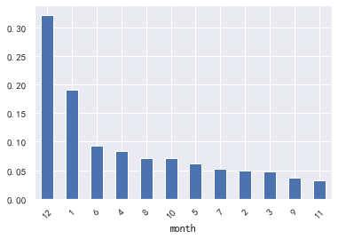

```python
bb.loc[2011].sort_values(ascending = False).plot(kind='bar')#查看退货率排名
plt.xticks(rotation = 45)
```

```python
#查看退货率平均值
bb.loc[2011].mean()
```

```
0.09249438130255831
```

可以看出，12月份的退货率最高，可能是由于12月份相关节日影响，若要进一步分析，需要结合往年数据进行进一步分析，从而得出具体原因

### 用户分类

RFM模型：衡量客户价值和客户创利能力的重要手段和工具，通过一个客户的近期购买行为购买总体品频率以及花了多少钱来衡量客户的价值

```python
R_value = df2.groupby("CustomerID")['date'].max()
```

```python
R_value = (df2['date'].max() - R_value).dt.days
```

```python
R_value#每个客户最近的一次消费时间距离参考时间间隔，值越小越好
```

```
CustomerID
12346.0    325
12347.0      2
12348.0     75
12349.0     18
12350.0    310
12352.0     36
12353.0    204
12354.0    232
12355.0    214
12356.0     22
12357.0     33
12358.0      1
12359.0     57
12360.0     52
12361.0    287
12362.0      3
12363.0    109
12364.0      7
12365.0    291
12367.0      4
12370.0     51
12371.0     44
12372.0     71
12373.0    311
12374.0     25
12375.0     10
12377.0    315
12378.0    129
12379.0     81
12380.0     21
          ...
18245.0      7
18246.0     23
18248.0    122
18249.0     17
18250.0    310
18251.0     87
18252.0     50
18255.0     89
```

[output cut: 8 more lines]

```
18269.0    366
18270.0     38
18272.0      2
18273.0      2
18274.0     30
18276.0     43
18277.0     58
18278.0     73
18280.0    277
18281.0    180
18282.0      7
18283.0      3
18287.0     42
U            0
Name: date, Length: 4339, dtype: int64
```

```python
df2.info()
```

```
<class 'pandas.core.frame.DataFrame'>
Int64Index: 524876 entries, 0 to 541908
Data columns (total 12 columns):
InvoiceNo     524876 non-null object
StockCode     524876 non-null object
Quantity      524876 non-null int64
UnitPrice     524876 non-null float64
CustomerID    524876 non-null object
Country       524876 non-null object
amount        524876 non-null float64
date          524876 non-null datetime64[ns]
time          524876 non-null object
year          524876 non-null int64
month         524876 non-null int64
day           524876 non-null int64
dtypes: datetime64[ns](1), float64(2), int64(4), object(5)
memory usage: 52.1+ MB
```

```python
#计算客户消费频次，以订单编号进行统计（先去重，再计数）按照客户维度计算客户不同订单编号的个数
F_value = df2.groupby("CustomerID")['InvoiceNo'].nunique()#nunique是先去重后计数
```

```python
F_value#值越大越好
```

```
CustomerID
12346.0       1
12347.0       7
12348.0       4
12349.0       1
12350.0       1
12352.0       8
12353.0       1
12354.0       1
12355.0       1
12356.0       3
12357.0       1
12358.0       2
12359.0       4
12360.0       3
12361.0       1
12362.0      10
12363.0       2
12364.0       4
12365.0       2
12367.0       1
12370.0       4
12371.0       2
12372.0       3
12373.0       1
12374.0       1
12375.0       2
12377.0       2
12378.0       1
12379.0       2
12380.0       4
           ...
18245.0       7
18246.0       2
18248.0       2
18249.0       1
18250.0       1
18251.0       1
18252.0       2
18255.0       1
```

[output cut: 8 more lines]

```
18269.0       1
18270.0       2
18272.0       6
18273.0       3
18274.0       1
18276.0       1
18277.0       1
18278.0       1
18280.0       1
18281.0       1
18282.0       2
18283.0      16
18287.0       3
U          1428
Name: InvoiceNo, Length: 4339, dtype: int64
```

```python
# df2:把退货的和可能是系统或者可能是赠品的数据剔除后的数据
M_value = df2.groupby("CustomerID")['amount'].sum()
```

```python
M_value
```

```
CustomerID
12346.0    7.718360e+04
12347.0    4.310000e+03
12348.0    1.797240e+03
12349.0    1.757550e+03
12350.0    3.344000e+02
12352.0    2.506040e+03
12353.0    8.900000e+01
12354.0    1.079400e+03
12355.0    4.594000e+02
12356.0    2.811430e+03
12357.0    6.207670e+03
12358.0    1.168060e+03
12359.0    6.310030e+03
12360.0    2.662060e+03
12361.0    1.899000e+02
12362.0    5.226230e+03
12363.0    5.520000e+02
12364.0    1.313100e+03
12365.0    6.413800e+02
12367.0    1.689000e+02
12370.0    3.541940e+03
12371.0    1.887960e+03
12372.0    1.298040e+03
12373.0    3.646000e+02
12374.0    7.429300e+02
12375.0    4.575000e+02
12377.0    1.628120e+03
12378.0    4.008620e+03
12379.0    8.522400e+02
12380.0    2.724810e+03
               ...
18245.0    2.567060e+03
18246.0    5.961000e+02
18248.0    8.040200e+02
18249.0    9.534000e+01
18250.0    3.492700e+02
18251.0    4.314720e+03
18252.0    5.182700e+02
18255.0    1.033000e+02
```

[output cut: 8 more lines]

```
18269.0    1.686000e+02
18270.0    2.831500e+02
18272.0    3.078580e+03
18273.0    2.040000e+02
18274.0    1.759200e+02
18276.0    3.358600e+02
18277.0    1.103800e+02
18278.0    1.739000e+02
18280.0    1.806000e+02
18281.0    8.082000e+01
18282.0    1.780500e+02
18283.0    2.045530e+03
18287.0    1.837280e+03
U          1.754902e+06
Name: amount, Length: 4339, dtype: float64
```

```python
R_value.describe()
```

```
count    4339.000000
mean       92.038258
std       100.010502
min         0.000000
25%        17.000000
50%        50.000000
75%       141.500000
max       373.000000
Name: date, dtype: float64
```

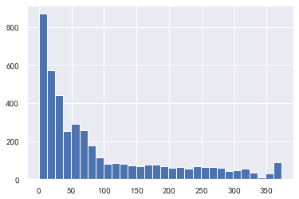

```python
#绘制R_value分布图
plt.hist(R_value,bins = 30)
plt.show()
```

```python
M_value.describe()
```

```
count    4.339000e+03
mean     2.452537e+03
std      2.808589e+04
min      3.750000e+00
25%      3.065050e+02
50%      6.685800e+02
75%      1.660890e+03
max      1.754902e+06
Name: amount, dtype: float64
```

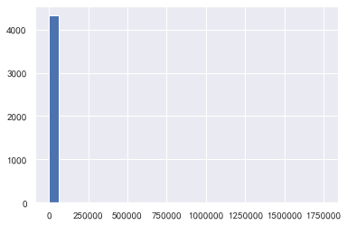

```python
plt.hist(M_value,bins = 30)
plt.show()
#判断异常值看均值和中位数的差距大不大
```

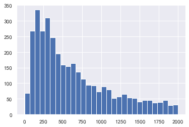

```python
plt.hist(M_value[M_value<2000],bins = 30)
plt.show()
```

```python
F_value.describe()
```

```
count    4339.000000
mean        4.600138
std        22.943499
min         1.000000
25%         1.000000
50%         2.000000
75%         5.000000
max      1428.000000
Name: InvoiceNo, dtype: float64
```

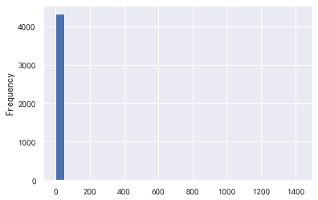

```python
#查看消费频次
F_value.plot(kind = 'hist',bins = 30)#一根柱子表示异常值严重
```

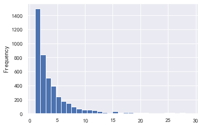

```python
F_value[F_value < 30].plot(kind='hist',bins=30)
```

```python
#对R_value 分级
R_bins = [0,30,90,180,360,720]#也可以根据实际业务分级，一个月，三个月以内，半年，一年,分为五个间隔
F_bins = [1,2,5,10,20,5000]#单位时间内消费的次数为消费频次
M_bins = [0,500,2000,5000,10000,200000]
```

```python
# F_value.quantile([0.1,0.2,0.3,0.4,0.5,0.9,1.0])#参考如何进行分层
```

```python
#对数据进行切分
R_score = pd.cut(R_value,R_bins,labels=[5,4,3,2,1],right=False)#不包含右边，数字越大越有价值
```

```python
R_score
```

```
CustomerID
12346.0    2
12347.0    5
12348.0    4
12349.0    5
12350.0    2
12352.0    4
12353.0    2
12354.0    2
12355.0    2
12356.0    5
12357.0    4
12358.0    5
12359.0    4
12360.0    4
12361.0    2
12362.0    5
12363.0    3
12364.0    5
12365.0    2
12367.0    5
12370.0    4
12371.0    4
12372.0    4
12373.0    2
12374.0    5
12375.0    5
12377.0    2
12378.0    3
12379.0    4
12380.0    5
          ..
18245.0    5
18246.0    5
18248.0    3
18249.0    5
18250.0    2
18251.0    4
18252.0    4
18255.0    4
```

[output cut: 9 more lines]

```
18270.0    4
18272.0    5
18273.0    5
18274.0    4
18276.0    4
18277.0    4
18278.0    4
18280.0    2
18281.0    2
18282.0    5
18283.0    5
18287.0    4
U          5
Name: date, Length: 4339, dtype: category
Categories (5, int64): [5 < 4 < 3 < 2 < 1]
```

```python
F_score = pd.cut(F_value,F_bins,labels=[1,2,3,4,5],right = False)#值越大越好
```

```python
F_score
```

```
CustomerID
12346.0    1
12347.0    3
12348.0    2
12349.0    1
12350.0    1
12352.0    3
12353.0    1
12354.0    1
12355.0    1
12356.0    2
12357.0    1
12358.0    2
12359.0    2
12360.0    2
12361.0    1
12362.0    4
12363.0    2
12364.0    2
12365.0    2
12367.0    1
12370.0    2
12371.0    2
12372.0    2
12373.0    1
12374.0    1
12375.0    2
12377.0    2
12378.0    1
12379.0    2
12380.0    2
          ..
18245.0    3
18246.0    2
18248.0    2
18249.0    1
18250.0    1
18251.0    1
18252.0    2
18255.0    1
```

[output cut: 9 more lines]

```
18270.0    2
18272.0    3
18273.0    2
18274.0    1
18276.0    1
18277.0    1
18278.0    1
18280.0    1
18281.0    1
18282.0    2
18283.0    4
18287.0    2
U          5
Name: InvoiceNo, Length: 4339, dtype: category
Categories (5, int64): [1 < 2 < 3 < 4 < 5]
```

```python
M_score = pd.cut(M_value,M_bins,labels=[1,2,3,4,5],right=False)
```

```python
M_score
```

```
CustomerID
12346.0      5
12347.0      3
12348.0      2
12349.0      2
12350.0      1
12352.0      3
12353.0      1
12354.0      2
12355.0      1
12356.0      3
12357.0      4
12358.0      2
12359.0      4
12360.0      3
12361.0      1
12362.0      4
12363.0      2
12364.0      2
12365.0      2
12367.0      1
12370.0      3
12371.0      2
12372.0      2
12373.0      1
12374.0      2
12375.0      1
12377.0      2
12378.0      3
12379.0      2
12380.0      3
          ...
18245.0      3
18246.0      2
18248.0      2
18249.0      1
18250.0      1
18251.0      3
18252.0      2
18255.0      1
```

[output cut: 9 more lines]

```
18270.0      1
18272.0      3
18273.0      1
18274.0      1
18276.0      1
18277.0      1
18278.0      1
18280.0      1
18281.0      1
18282.0      1
18283.0      3
18287.0      2
U          NaN
Name: amount, Length: 4339, dtype: category
Categories (5, int64): [1 < 2 < 3 < 4 < 5]
```

```python
#创建RFM对三者合并
rfm = pd.concat([R_score,F_score,M_score],axis = 1)
```

```python
rfm
```

| CustomerID | date | InvoiceNo | amount |
| --- | --- | --- | --- |
| 12346.0 | 2 | 1 | 5 |
| 12347.0 | 5 | 3 | 3 |
| 12348.0 | 4 | 2 | 2 |
| 12349.0 | 5 | 1 | 2 |
| 12350.0 | 2 | 1 | 1 |
| 12352.0 | 4 | 3 | 3 |
| 12353.0 | 2 | 1 | 1 |
| 12354.0 | 2 | 1 | 2 |
| 12355.0 | 2 | 1 | 1 |
| 12356.0 | 5 | 2 | 3 |
| 12357.0 | 4 | 1 | 4 |
| 12358.0 | 5 | 2 | 2 |
| 12359.0 | 4 | 2 | 4 |
| 12360.0 | 4 | 2 | 3 |
| 12361.0 | 2 | 1 | 1 |
| 12362.0 | 5 | 4 | 4 |
| 12363.0 | 3 | 2 | 2 |
| 12364.0 | 5 | 2 | 2 |
| 12365.0 | 2 | 2 | 2 |
| 12367.0 | 5 | 1 | 1 |
| 12370.0 | 4 | 2 | 3 |
| 12371.0 | 4 | 2 | 2 |
| 12372.0 | 4 | 2 | 2 |
| 12373.0 | 2 | 1 | 1 |
| 12374.0 | 5 | 1 | 2 |
| 12375.0 | 5 | 2 | 1 |
| 12377.0 | 2 | 2 | 2 |
| 12378.0 | 3 | 1 | 3 |
| 12379.0 | 4 | 2 | 2 |
| 12380.0 | 5 | 2 | 3 |
| ... | ... | ... | ... |
| 18245.0 | 5 | 3 | 3 |
| 18246.0 | 5 | 2 | 2 |
| 18248.0 | 3 | 2 | 2 |
| 18249.0 | 5 | 1 | 1 |
| 18250.0 | 2 | 1 | 1 |
| 18251.0 | 4 | 1 | 3 |
| 18252.0 | 4 | 2 | 2 |
| 18255.0 | 4 | 1 | 1 |
| 18257.0 | 4 | 3 | 3 |
| 18259.0 | 5 | 2 | 3 |
| 18260.0 | 3 | 3 | 3 |
| 18261.0 | 4 | 2 | 1 |
| 18262.0 | 3 | 1 | 1 |
| 18263.0 | 5 | 2 | 2 |
| 18265.0 | 4 | 2 | 2 |
| 18268.0 | 3 | 1 | 1 |
| 18269.0 | 1 | 1 | 1 |
| 18270.0 | 4 | 2 | 1 |
| 18272.0 | 5 | 3 | 3 |
| 18273.0 | 5 | 2 | 1 |
| 18274.0 | 4 | 1 | 1 |
| 18276.0 | 4 | 1 | 1 |
| 18277.0 | 4 | 1 | 1 |
| 18278.0 | 4 | 1 | 1 |
| 18280.0 | 2 | 1 | 1 |
| 18281.0 | 2 | 1 | 1 |
| 18282.0 | 5 | 2 | 1 |
| 18283.0 | 5 | 4 | 3 |
| 18287.0 | 4 | 2 | 2 |
| U | 5 | 5 | NaN |

4339 rows × 3 columns

```python
rfm.info()
```

```
<class 'pandas.core.frame.DataFrame'>
Index: 4339 entries, 12346.0 to U
Data columns (total 3 columns):
date         4339 non-null category
InvoiceNo    4339 non-null category
amount       4336 non-null category
dtypes: category(3)
memory usage: 207.2+ KB
```

```python
rfm.rename(columns={'date':'R_score','InvoiceNo':'F_score','amount':'M_score'},inplace=True)
```

```python
rfm
```

| CustomerID | R_score | F_score | M_score |
| --- | --- | --- | --- |
| 12346.0 | 2 | 1 | 5 |
| 12347.0 | 5 | 3 | 3 |
| 12348.0 | 4 | 2 | 2 |
| 12349.0 | 5 | 1 | 2 |
| 12350.0 | 2 | 1 | 1 |
| 12352.0 | 4 | 3 | 3 |
| 12353.0 | 2 | 1 | 1 |
| 12354.0 | 2 | 1 | 2 |
| 12355.0 | 2 | 1 | 1 |
| 12356.0 | 5 | 2 | 3 |
| 12357.0 | 4 | 1 | 4 |
| 12358.0 | 5 | 2 | 2 |
| 12359.0 | 4 | 2 | 4 |
| 12360.0 | 4 | 2 | 3 |
| 12361.0 | 2 | 1 | 1 |
| 12362.0 | 5 | 4 | 4 |
| 12363.0 | 3 | 2 | 2 |
| 12364.0 | 5 | 2 | 2 |
| 12365.0 | 2 | 2 | 2 |
| 12367.0 | 5 | 1 | 1 |
| 12370.0 | 4 | 2 | 3 |
| 12371.0 | 4 | 2 | 2 |
| 12372.0 | 4 | 2 | 2 |
| 12373.0 | 2 | 1 | 1 |
| 12374.0 | 5 | 1 | 2 |
| 12375.0 | 5 | 2 | 1 |
| 12377.0 | 2 | 2 | 2 |
| 12378.0 | 3 | 1 | 3 |
| 12379.0 | 4 | 2 | 2 |
| 12380.0 | 5 | 2 | 3 |
| ... | ... | ... | ... |
| 18245.0 | 5 | 3 | 3 |
| 18246.0 | 5 | 2 | 2 |
| 18248.0 | 3 | 2 | 2 |
| 18249.0 | 5 | 1 | 1 |
| 18250.0 | 2 | 1 | 1 |
| 18251.0 | 4 | 1 | 3 |
| 18252.0 | 4 | 2 | 2 |
| 18255.0 | 4 | 1 | 1 |
| 18257.0 | 4 | 3 | 3 |
| 18259.0 | 5 | 2 | 3 |
| 18260.0 | 3 | 3 | 3 |
| 18261.0 | 4 | 2 | 1 |
| 18262.0 | 3 | 1 | 1 |
| 18263.0 | 5 | 2 | 2 |
| 18265.0 | 4 | 2 | 2 |
| 18268.0 | 3 | 1 | 1 |
| 18269.0 | 1 | 1 | 1 |
| 18270.0 | 4 | 2 | 1 |
| 18272.0 | 5 | 3 | 3 |
| 18273.0 | 5 | 2 | 1 |
| 18274.0 | 4 | 1 | 1 |
| 18276.0 | 4 | 1 | 1 |
| 18277.0 | 4 | 1 | 1 |
| 18278.0 | 4 | 1 | 1 |
| 18280.0 | 2 | 1 | 1 |
| 18281.0 | 2 | 1 | 1 |
| 18282.0 | 5 | 2 | 1 |
| 18283.0 | 5 | 4 | 3 |
| 18287.0 | 4 | 2 | 2 |
| U | 5 | 5 | NaN |

4339 rows × 3 columns

```python
#客户编号是缺失值，不用在意为什么是缺失值（为什么是缺失值）
```

```python
#数据类性转换
rfm.info()
```

```
<class 'pandas.core.frame.DataFrame'>
Index: 4339 entries, 12346.0 to U
Data columns (total 3 columns):
R_score    4339 non-null category
F_score    4339 non-null category
M_score    4336 non-null category
dtypes: category(3)
memory usage: 47.2+ KB
```

```python
for i in rfm.columns.tolist():
    rfm[i] = rfm[i].astype(float)#数据类型转换，也可以rfm.astype(float,inplace=True)
```

```python
rfm.info()
```

```
<class 'pandas.core.frame.DataFrame'>
Index: 4339 entries, 12346.0 to U
Data columns (total 3 columns):
R_score    4339 non-null float64
F_score    4339 non-null float64
M_score    4336 non-null float64
dtypes: float64(3)
memory usage: 135.6+ KB
```

```python
rfm.describe()
```

|  | R_score | F_score | M_score |
| --- | --- | --- | --- |
| count | 4339.000000 | 4339.000000 | 4336.000000 |
| mean | 3.821618 | 2.028117 | 1.885609 |
| std | 1.174880 | 0.997989 | 0.951810 |
| min | 1.000000 | 1.000000 | 1.000000 |
| 25% | 3.000000 | 1.000000 | 1.000000 |
| 50% | 4.000000 | 2.000000 | 2.000000 |
| 75% | 5.000000 | 3.000000 | 2.000000 |
| max | 5.000000 | 5.000000 | 5.000000 |

```python
rfm['R'] = np.where(rfm['R_score'] > 3.82,'高','低')
rfm['F'] = np.where(rfm['F_score'] > 2.03,'高','低')
rfm['M'] = np.where(rfm['M_score'] > 1.89,'高','低')
```

```python
rfm
```

| CustomerID | R_score | F_score | M_score | R | F | M |
| --- | --- | --- | --- | --- | --- | --- |
| 12346.0 | 2.0 | 1.0 | 5.0 | 低 | 低 | 高 |
| 12347.0 | 5.0 | 3.0 | 3.0 | 高 | 高 | 高 |
| 12348.0 | 4.0 | 2.0 | 2.0 | 高 | 低 | 高 |
| 12349.0 | 5.0 | 1.0 | 2.0 | 高 | 低 | 高 |
| 12350.0 | 2.0 | 1.0 | 1.0 | 低 | 低 | 低 |
| 12352.0 | 4.0 | 3.0 | 3.0 | 高 | 高 | 高 |
| 12353.0 | 2.0 | 1.0 | 1.0 | 低 | 低 | 低 |
| 12354.0 | 2.0 | 1.0 | 2.0 | 低 | 低 | 高 |
| 12355.0 | 2.0 | 1.0 | 1.0 | 低 | 低 | 低 |
| 12356.0 | 5.0 | 2.0 | 3.0 | 高 | 低 | 高 |
| 12357.0 | 4.0 | 1.0 | 4.0 | 高 | 低 | 高 |
| 12358.0 | 5.0 | 2.0 | 2.0 | 高 | 低 | 高 |
| 12359.0 | 4.0 | 2.0 | 4.0 | 高 | 低 | 高 |
| 12360.0 | 4.0 | 2.0 | 3.0 | 高 | 低 | 高 |
| 12361.0 | 2.0 | 1.0 | 1.0 | 低 | 低 | 低 |
| 12362.0 | 5.0 | 4.0 | 4.0 | 高 | 高 | 高 |
| 12363.0 | 3.0 | 2.0 | 2.0 | 低 | 低 | 高 |
| 12364.0 | 5.0 | 2.0 | 2.0 | 高 | 低 | 高 |
| 12365.0 | 2.0 | 2.0 | 2.0 | 低 | 低 | 高 |
| 12367.0 | 5.0 | 1.0 | 1.0 | 高 | 低 | 低 |
| 12370.0 | 4.0 | 2.0 | 3.0 | 高 | 低 | 高 |
| 12371.0 | 4.0 | 2.0 | 2.0 | 高 | 低 | 高 |
| 12372.0 | 4.0 | 2.0 | 2.0 | 高 | 低 | 高 |
| 12373.0 | 2.0 | 1.0 | 1.0 | 低 | 低 | 低 |
| 12374.0 | 5.0 | 1.0 | 2.0 | 高 | 低 | 高 |
| 12375.0 | 5.0 | 2.0 | 1.0 | 高 | 低 | 低 |
| 12377.0 | 2.0 | 2.0 | 2.0 | 低 | 低 | 高 |
| 12378.0 | 3.0 | 1.0 | 3.0 | 低 | 低 | 高 |
| 12379.0 | 4.0 | 2.0 | 2.0 | 高 | 低 | 高 |
| 12380.0 | 5.0 | 2.0 | 3.0 | 高 | 低 | 高 |
| ... | ... | ... | ... | ... | ... | ... |
| 18245.0 | 5.0 | 3.0 | 3.0 | 高 | 高 | 高 |
| 18246.0 | 5.0 | 2.0 | 2.0 | 高 | 低 | 高 |
| 18248.0 | 3.0 | 2.0 | 2.0 | 低 | 低 | 高 |
| 18249.0 | 5.0 | 1.0 | 1.0 | 高 | 低 | 低 |
| 18250.0 | 2.0 | 1.0 | 1.0 | 低 | 低 | 低 |
| 18251.0 | 4.0 | 1.0 | 3.0 | 高 | 低 | 高 |
| 18252.0 | 4.0 | 2.0 | 2.0 | 高 | 低 | 高 |
| 18255.0 | 4.0 | 1.0 | 1.0 | 高 | 低 | 低 |
| 18257.0 | 4.0 | 3.0 | 3.0 | 高 | 高 | 高 |
| 18259.0 | 5.0 | 2.0 | 3.0 | 高 | 低 | 高 |
| 18260.0 | 3.0 | 3.0 | 3.0 | 低 | 高 | 高 |
| 18261.0 | 4.0 | 2.0 | 1.0 | 高 | 低 | 低 |
| 18262.0 | 3.0 | 1.0 | 1.0 | 低 | 低 | 低 |
| 18263.0 | 5.0 | 2.0 | 2.0 | 高 | 低 | 高 |
| 18265.0 | 4.0 | 2.0 | 2.0 | 高 | 低 | 高 |
| 18268.0 | 3.0 | 1.0 | 1.0 | 低 | 低 | 低 |
| 18269.0 | 1.0 | 1.0 | 1.0 | 低 | 低 | 低 |
| 18270.0 | 4.0 | 2.0 | 1.0 | 高 | 低 | 低 |
| 18272.0 | 5.0 | 3.0 | 3.0 | 高 | 高 | 高 |
| 18273.0 | 5.0 | 2.0 | 1.0 | 高 | 低 | 低 |
| 18274.0 | 4.0 | 1.0 | 1.0 | 高 | 低 | 低 |
| 18276.0 | 4.0 | 1.0 | 1.0 | 高 | 低 | 低 |
| 18277.0 | 4.0 | 1.0 | 1.0 | 高 | 低 | 低 |
| 18278.0 | 4.0 | 1.0 | 1.0 | 高 | 低 | 低 |
| 18280.0 | 2.0 | 1.0 | 1.0 | 低 | 低 | 低 |
| 18281.0 | 2.0 | 1.0 | 1.0 | 低 | 低 | 低 |
| 18282.0 | 5.0 | 2.0 | 1.0 | 高 | 低 | 低 |
| 18283.0 | 5.0 | 4.0 | 3.0 | 高 | 高 | 高 |
| 18287.0 | 4.0 | 2.0 | 2.0 | 高 | 低 | 高 |
| U | 5.0 | 5.0 | NaN | 高 | 高 | 低 |

4339 rows × 6 columns

```python
rfm['value'] = rfm.apply(lambda x : x[3] + x[4] + x[5],axis = 1)
```

```python
rfm
```

| CustomerID | R_score | F_score | M_score | R | F | M | value |
| --- | --- | --- | --- | --- | --- | --- | --- |
| 12346.0 | 2.0 | 1.0 | 5.0 | 低 | 低 | 高 | 低低高 |
| 12347.0 | 5.0 | 3.0 | 3.0 | 高 | 高 | 高 | 高高高 |
| 12348.0 | 4.0 | 2.0 | 2.0 | 高 | 低 | 高 | 高低高 |
| 12349.0 | 5.0 | 1.0 | 2.0 | 高 | 低 | 高 | 高低高 |
| 12350.0 | 2.0 | 1.0 | 1.0 | 低 | 低 | 低 | 低低低 |
| 12352.0 | 4.0 | 3.0 | 3.0 | 高 | 高 | 高 | 高高高 |
| 12353.0 | 2.0 | 1.0 | 1.0 | 低 | 低 | 低 | 低低低 |
| 12354.0 | 2.0 | 1.0 | 2.0 | 低 | 低 | 高 | 低低高 |
| 12355.0 | 2.0 | 1.0 | 1.0 | 低 | 低 | 低 | 低低低 |
| 12356.0 | 5.0 | 2.0 | 3.0 | 高 | 低 | 高 | 高低高 |
| 12357.0 | 4.0 | 1.0 | 4.0 | 高 | 低 | 高 | 高低高 |
| 12358.0 | 5.0 | 2.0 | 2.0 | 高 | 低 | 高 | 高低高 |
| 12359.0 | 4.0 | 2.0 | 4.0 | 高 | 低 | 高 | 高低高 |
| 12360.0 | 4.0 | 2.0 | 3.0 | 高 | 低 | 高 | 高低高 |
| 12361.0 | 2.0 | 1.0 | 1.0 | 低 | 低 | 低 | 低低低 |
| 12362.0 | 5.0 | 4.0 | 4.0 | 高 | 高 | 高 | 高高高 |
| 12363.0 | 3.0 | 2.0 | 2.0 | 低 | 低 | 高 | 低低高 |
| 12364.0 | 5.0 | 2.0 | 2.0 | 高 | 低 | 高 | 高低高 |
| 12365.0 | 2.0 | 2.0 | 2.0 | 低 | 低 | 高 | 低低高 |
| 12367.0 | 5.0 | 1.0 | 1.0 | 高 | 低 | 低 | 高低低 |
| 12370.0 | 4.0 | 2.0 | 3.0 | 高 | 低 | 高 | 高低高 |
| 12371.0 | 4.0 | 2.0 | 2.0 | 高 | 低 | 高 | 高低高 |
| 12372.0 | 4.0 | 2.0 | 2.0 | 高 | 低 | 高 | 高低高 |
| 12373.0 | 2.0 | 1.0 | 1.0 | 低 | 低 | 低 | 低低低 |
| 12374.0 | 5.0 | 1.0 | 2.0 | 高 | 低 | 高 | 高低高 |
| 12375.0 | 5.0 | 2.0 | 1.0 | 高 | 低 | 低 | 高低低 |
| 12377.0 | 2.0 | 2.0 | 2.0 | 低 | 低 | 高 | 低低高 |
| 12378.0 | 3.0 | 1.0 | 3.0 | 低 | 低 | 高 | 低低高 |
| 12379.0 | 4.0 | 2.0 | 2.0 | 高 | 低 | 高 | 高低高 |
| 12380.0 | 5.0 | 2.0 | 3.0 | 高 | 低 | 高 | 高低高 |
| ... | ... | ... | ... | ... | ... | ... | ... |
| 18245.0 | 5.0 | 3.0 | 3.0 | 高 | 高 | 高 | 高高高 |
| 18246.0 | 5.0 | 2.0 | 2.0 | 高 | 低 | 高 | 高低高 |
| 18248.0 | 3.0 | 2.0 | 2.0 | 低 | 低 | 高 | 低低高 |
| 18249.0 | 5.0 | 1.0 | 1.0 | 高 | 低 | 低 | 高低低 |
| 18250.0 | 2.0 | 1.0 | 1.0 | 低 | 低 | 低 | 低低低 |
| 18251.0 | 4.0 | 1.0 | 3.0 | 高 | 低 | 高 | 高低高 |
| 18252.0 | 4.0 | 2.0 | 2.0 | 高 | 低 | 高 | 高低高 |
| 18255.0 | 4.0 | 1.0 | 1.0 | 高 | 低 | 低 | 高低低 |
| 18257.0 | 4.0 | 3.0 | 3.0 | 高 | 高 | 高 | 高高高 |
| 18259.0 | 5.0 | 2.0 | 3.0 | 高 | 低 | 高 | 高低高 |
| 18260.0 | 3.0 | 3.0 | 3.0 | 低 | 高 | 高 | 低高高 |
| 18261.0 | 4.0 | 2.0 | 1.0 | 高 | 低 | 低 | 高低低 |
| 18262.0 | 3.0 | 1.0 | 1.0 | 低 | 低 | 低 | 低低低 |
| 18263.0 | 5.0 | 2.0 | 2.0 | 高 | 低 | 高 | 高低高 |
| 18265.0 | 4.0 | 2.0 | 2.0 | 高 | 低 | 高 | 高低高 |
| 18268.0 | 3.0 | 1.0 | 1.0 | 低 | 低 | 低 | 低低低 |
| 18269.0 | 1.0 | 1.0 | 1.0 | 低 | 低 | 低 | 低低低 |
| 18270.0 | 4.0 | 2.0 | 1.0 | 高 | 低 | 低 | 高低低 |
| 18272.0 | 5.0 | 3.0 | 3.0 | 高 | 高 | 高 | 高高高 |
| 18273.0 | 5.0 | 2.0 | 1.0 | 高 | 低 | 低 | 高低低 |
| 18274.0 | 4.0 | 1.0 | 1.0 | 高 | 低 | 低 | 高低低 |
| 18276.0 | 4.0 | 1.0 | 1.0 | 高 | 低 | 低 | 高低低 |
| 18277.0 | 4.0 | 1.0 | 1.0 | 高 | 低 | 低 | 高低低 |
| 18278.0 | 4.0 | 1.0 | 1.0 | 高 | 低 | 低 | 高低低 |
| 18280.0 | 2.0 | 1.0 | 1.0 | 低 | 低 | 低 | 低低低 |
| 18281.0 | 2.0 | 1.0 | 1.0 | 低 | 低 | 低 | 低低低 |
| 18282.0 | 5.0 | 2.0 | 1.0 | 高 | 低 | 低 | 高低低 |
| 18283.0 | 5.0 | 4.0 | 3.0 | 高 | 高 | 高 | 高高高 |
| 18287.0 | 4.0 | 2.0 | 2.0 | 高 | 低 | 高 | 高低高 |
| U | 5.0 | 5.0 | NaN | 高 | 高 | 低 | 高高低 |

4339 rows × 7 columns

```python
# rfm.groupby('value').count()
```

```python
#汇总分层结果
def trans_value(x):
    if x == '高高高':
        return "重要价值客户"
    elif x == '高低高':
        return '重要发展客户'
    elif x == '低高高':
        return '重要保持客户'
    elif x == '低低高':
        return "重要挽留客户"
    elif x == '高高低':
        return '一般价值客户'
    elif x == '高低低':
        return '一般发展客户'
    elif x == '低高低':
        return '一般保持客户'
    else:
        return '一般挽留客户'
```

```python
rfm['用户等级'] = rfm['value'].apply(trans_value)
```

```python
rfm
```

| CustomerID | R_score | F_score | M_score | R | F | M | value | 用户等级 |
| --- | --- | --- | --- | --- | --- | --- | --- | --- |
| 12346.0 | 2.0 | 1.0 | 5.0 | 低 | 低 | 高 | 低低高 | 重要挽留客户 |
| 12347.0 | 5.0 | 3.0 | 3.0 | 高 | 高 | 高 | 高高高 | 重要价值客户 |
| 12348.0 | 4.0 | 2.0 | 2.0 | 高 | 低 | 高 | 高低高 | 重要发展客户 |
| 12349.0 | 5.0 | 1.0 | 2.0 | 高 | 低 | 高 | 高低高 | 重要发展客户 |
| 12350.0 | 2.0 | 1.0 | 1.0 | 低 | 低 | 低 | 低低低 | 一般挽留客户 |
| 12352.0 | 4.0 | 3.0 | 3.0 | 高 | 高 | 高 | 高高高 | 重要价值客户 |
| 12353.0 | 2.0 | 1.0 | 1.0 | 低 | 低 | 低 | 低低低 | 一般挽留客户 |
| 12354.0 | 2.0 | 1.0 | 2.0 | 低 | 低 | 高 | 低低高 | 重要挽留客户 |
| 12355.0 | 2.0 | 1.0 | 1.0 | 低 | 低 | 低 | 低低低 | 一般挽留客户 |
| 12356.0 | 5.0 | 2.0 | 3.0 | 高 | 低 | 高 | 高低高 | 重要发展客户 |
| 12357.0 | 4.0 | 1.0 | 4.0 | 高 | 低 | 高 | 高低高 | 重要发展客户 |
| 12358.0 | 5.0 | 2.0 | 2.0 | 高 | 低 | 高 | 高低高 | 重要发展客户 |
| 12359.0 | 4.0 | 2.0 | 4.0 | 高 | 低 | 高 | 高低高 | 重要发展客户 |
| 12360.0 | 4.0 | 2.0 | 3.0 | 高 | 低 | 高 | 高低高 | 重要发展客户 |
| 12361.0 | 2.0 | 1.0 | 1.0 | 低 | 低 | 低 | 低低低 | 一般挽留客户 |
| 12362.0 | 5.0 | 4.0 | 4.0 | 高 | 高 | 高 | 高高高 | 重要价值客户 |
| 12363.0 | 3.0 | 2.0 | 2.0 | 低 | 低 | 高 | 低低高 | 重要挽留客户 |
| 12364.0 | 5.0 | 2.0 | 2.0 | 高 | 低 | 高 | 高低高 | 重要发展客户 |
| 12365.0 | 2.0 | 2.0 | 2.0 | 低 | 低 | 高 | 低低高 | 重要挽留客户 |
| 12367.0 | 5.0 | 1.0 | 1.0 | 高 | 低 | 低 | 高低低 | 一般发展客户 |
| 12370.0 | 4.0 | 2.0 | 3.0 | 高 | 低 | 高 | 高低高 | 重要发展客户 |
| 12371.0 | 4.0 | 2.0 | 2.0 | 高 | 低 | 高 | 高低高 | 重要发展客户 |
| 12372.0 | 4.0 | 2.0 | 2.0 | 高 | 低 | 高 | 高低高 | 重要发展客户 |
| 12373.0 | 2.0 | 1.0 | 1.0 | 低 | 低 | 低 | 低低低 | 一般挽留客户 |
| 12374.0 | 5.0 | 1.0 | 2.0 | 高 | 低 | 高 | 高低高 | 重要发展客户 |
| 12375.0 | 5.0 | 2.0 | 1.0 | 高 | 低 | 低 | 高低低 | 一般发展客户 |
| 12377.0 | 2.0 | 2.0 | 2.0 | 低 | 低 | 高 | 低低高 | 重要挽留客户 |
| 12378.0 | 3.0 | 1.0 | 3.0 | 低 | 低 | 高 | 低低高 | 重要挽留客户 |
| 12379.0 | 4.0 | 2.0 | 2.0 | 高 | 低 | 高 | 高低高 | 重要发展客户 |
| 12380.0 | 5.0 | 2.0 | 3.0 | 高 | 低 | 高 | 高低高 | 重要发展客户 |
| ... | ... | ... | ... | ... | ... | ... | ... | ... |
| 18245.0 | 5.0 | 3.0 | 3.0 | 高 | 高 | 高 | 高高高 | 重要价值客户 |
| 18246.0 | 5.0 | 2.0 | 2.0 | 高 | 低 | 高 | 高低高 | 重要发展客户 |
| 18248.0 | 3.0 | 2.0 | 2.0 | 低 | 低 | 高 | 低低高 | 重要挽留客户 |
| 18249.0 | 5.0 | 1.0 | 1.0 | 高 | 低 | 低 | 高低低 | 一般发展客户 |
| 18250.0 | 2.0 | 1.0 | 1.0 | 低 | 低 | 低 | 低低低 | 一般挽留客户 |
| 18251.0 | 4.0 | 1.0 | 3.0 | 高 | 低 | 高 | 高低高 | 重要发展客户 |
| 18252.0 | 4.0 | 2.0 | 2.0 | 高 | 低 | 高 | 高低高 | 重要发展客户 |
| 18255.0 | 4.0 | 1.0 | 1.0 | 高 | 低 | 低 | 高低低 | 一般发展客户 |
| 18257.0 | 4.0 | 3.0 | 3.0 | 高 | 高 | 高 | 高高高 | 重要价值客户 |
| 18259.0 | 5.0 | 2.0 | 3.0 | 高 | 低 | 高 | 高低高 | 重要发展客户 |
| 18260.0 | 3.0 | 3.0 | 3.0 | 低 | 高 | 高 | 低高高 | 重要保持客户 |
| 18261.0 | 4.0 | 2.0 | 1.0 | 高 | 低 | 低 | 高低低 | 一般发展客户 |
| 18262.0 | 3.0 | 1.0 | 1.0 | 低 | 低 | 低 | 低低低 | 一般挽留客户 |
| 18263.0 | 5.0 | 2.0 | 2.0 | 高 | 低 | 高 | 高低高 | 重要发展客户 |
| 18265.0 | 4.0 | 2.0 | 2.0 | 高 | 低 | 高 | 高低高 | 重要发展客户 |
| 18268.0 | 3.0 | 1.0 | 1.0 | 低 | 低 | 低 | 低低低 | 一般挽留客户 |
| 18269.0 | 1.0 | 1.0 | 1.0 | 低 | 低 | 低 | 低低低 | 一般挽留客户 |
| 18270.0 | 4.0 | 2.0 | 1.0 | 高 | 低 | 低 | 高低低 | 一般发展客户 |
| 18272.0 | 5.0 | 3.0 | 3.0 | 高 | 高 | 高 | 高高高 | 重要价值客户 |
| 18273.0 | 5.0 | 2.0 | 1.0 | 高 | 低 | 低 | 高低低 | 一般发展客户 |
| 18274.0 | 4.0 | 1.0 | 1.0 | 高 | 低 | 低 | 高低低 | 一般发展客户 |
| 18276.0 | 4.0 | 1.0 | 1.0 | 高 | 低 | 低 | 高低低 | 一般发展客户 |
| 18277.0 | 4.0 | 1.0 | 1.0 | 高 | 低 | 低 | 高低低 | 一般发展客户 |
| 18278.0 | 4.0 | 1.0 | 1.0 | 高 | 低 | 低 | 高低低 | 一般发展客户 |
| 18280.0 | 2.0 | 1.0 | 1.0 | 低 | 低 | 低 | 低低低 | 一般挽留客户 |
| 18281.0 | 2.0 | 1.0 | 1.0 | 低 | 低 | 低 | 低低低 | 一般挽留客户 |
| 18282.0 | 5.0 | 2.0 | 1.0 | 高 | 低 | 低 | 高低低 | 一般发展客户 |
| 18283.0 | 5.0 | 4.0 | 3.0 | 高 | 高 | 高 | 高高高 | 重要价值客户 |
| 18287.0 | 4.0 | 2.0 | 2.0 | 高 | 低 | 高 | 高低高 | 重要发展客户 |
| U | 5.0 | 5.0 | NaN | 高 | 高 | 低 | 高高低 | 一般价值客户 |

4339 rows × 8 columns

```python
rfm['用户等级'].value_counts()
```

```
重要价值客户    1034
重要发展客户    1017
一般挽留客户     923
一般发展客户     829
重要挽留客户     455
重要保持客户      66
一般价值客户      10
一般保持客户       5
Name: 用户等级, dtype: int64
```

```python
fg = rfm['用户等级'].value_counts()
```

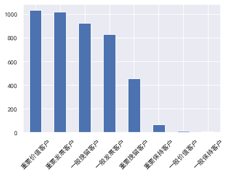

```python
fg.plot(kind='bar')
plt.xticks(rotation = 45)
```

```python
import plotly as py
import plotly.graph_objects as go
```

```python
pyout  = py.offline.iplot
```

```python
tran = go.Bar(x=fg.index.tolist(),y = fg.values.tolist())
layout = go.Layout(title='用户等级比例',xaxis=dict(title='用户等级'),yaxis=dict(title='用户数量'))
fig = go.Figure(data = [tran],layout=layout)
```

```python
pyout(fig)
```

[interactive chart not shown]

```python
#查看比例
tran0 = go.Pie(labels=fg.index.tolist(),values=fg.values.tolist(),hole=0.5,textfont=dict(color = 'white',size=15))
layout1 = go.Layout(title='用户等级比例')
fig1 = go.Figure(data = [tran0],layout=layout1)
```

```python
pyout(fig1)
```

[interactive chart not shown]

## 结论及建议

1. 根据相关指标对用户数据进行分类可以看出，重要价值客户和重要发展客户占比最高，我们需要引起重视，需要通过相关营销活动让重要发展客户更多的转化为重要价值客户。
2. 一般挽留客户和一般发展客户占比相对较多，同样需要让其转化为重要客户，提高公司的销售额。
3. 建议发展重要客户，提高一般客户向重要客户的转化率
4. 需要一定程度上提高产品质量和服务，从而降低退货率，提高收益